# Lab7

Anna Matarazzo

5/7/2021

## Problems

### Problem 1

1. Explain the concept of main effects and interactions with an example using R. For example, this could include a definition of main effects and interactions and a figure depicting main effects and an interaction along with an explanation of the patterns for each. A major point of this problem is for you to to engage in the task of developing an explanation of these concepts that would 1) be helpful for you to understand the concepts, and 2) could be helpful for others to understand these concepts. (3 points)

## My Version

When we plan an experiment with 2 independent variables (IV), we expect that our dependent variable (DV) will be affected by either one, both or none of the independent variables.

Let’s consider some examples.

1. On a nice summer day you decided to give away cold sweet treats to random people and measure how much do people like the treats on a scale from 1 to 10 (DV). You are offering people Ice-cream and Milkshake (IV-1) of two flavors - vanilla and strawberry (IV-2). The day was hot and the people were grateful for the free treats, so the mean Likeness Score for all the treats turned out to be 9.5 out of 10.

This is the example of an experiment were neither of the IVs nor their interaction had an effect on a DV.

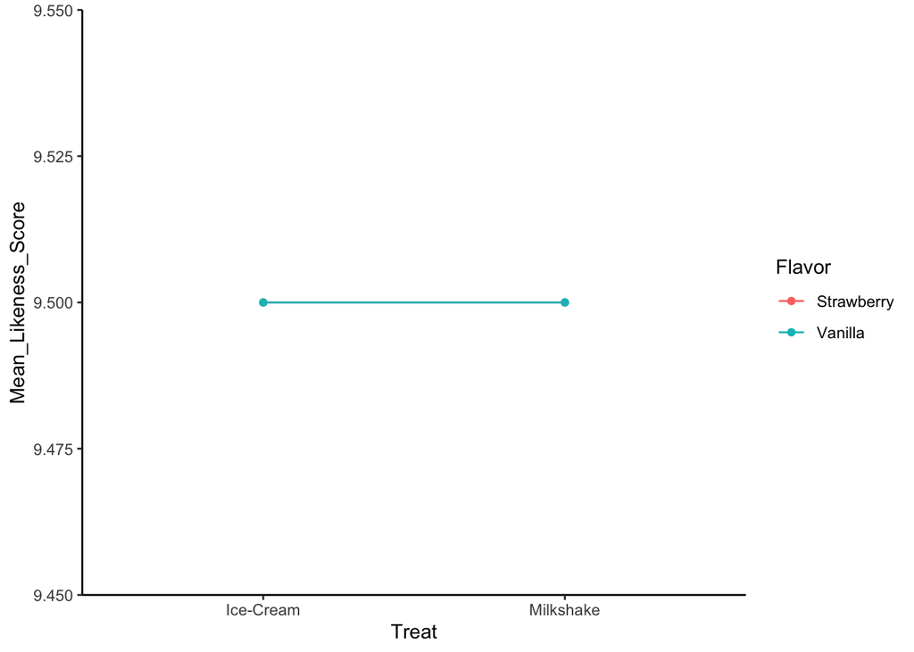

```r
library(tibble)
library(ggplot2)

No_Main_Effects <- tribble(~Treat, ~Flavor, ~Mean_Likeness_Score,
        "Ice-Cream", "Strawberry", 9.5,
        "Ice-Cream", "Vanilla", 9.5,
        "Milkshake", "Strawberry", 9.5,
        "Milkshake", "Vanilla", 9.5,
        )

ggplot(No_Main_Effects, aes(x=Treat, y=Mean_Likeness_Score, group=Flavor, color=Flavor))+
  geom_point()+
  geom_line()+
  theme_classic()
```

2. You decided to replicate your experiment on another day. However, something happened to the strawberry flavor (may have it gone bad?!) and unfortunately the milkshakes turned out to be a bit too watery. This time you see in your results that people liked ice-cream more than milkshakes (IV-1) AND they leaned towards vanilla flavor rather than the strawberry one (IV-2).

This is an example when both independent variables had an effect on a DV. There was no interaction effect.

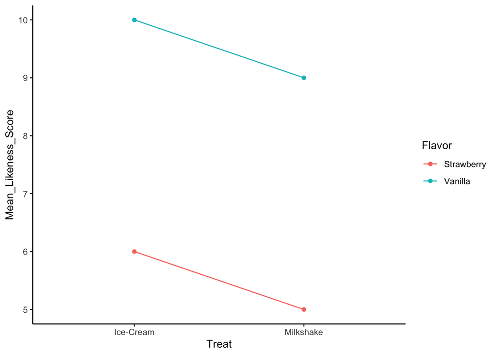

```r
Main_effect_A_and_B <- tribble(~Treat, ~Flavor, ~Mean_Likeness_Score,
        "Ice-Cream", "Strawberry", 6,
        "Ice-Cream", "Vanilla", 10,
        "Milkshake", "Strawberry", 5,
        "Milkshake", "Vanilla", 9,
        )

ggplot(Main_effect_A_and_B, aes(x=Treat, y=Mean_Likeness_Score, group=Flavor, color=Flavor))+
  geom_point()+
  geom_line()+
  theme_classic()
```

3. Now say you decided to establish whether people like pancakes more than an ice-cream (IV-1). You also want to see if the temperature of the treat (IV-2) has something to do with how much people like it (DV). Turned out that on average people like ice-cream as much as they like pancakes. Unsurprisingly, they prefer COLD ice-cream, but they would rather have their pancakes HOT.

This is the example of an interaction effect. There is no main effect of Treat or Temperature variables.

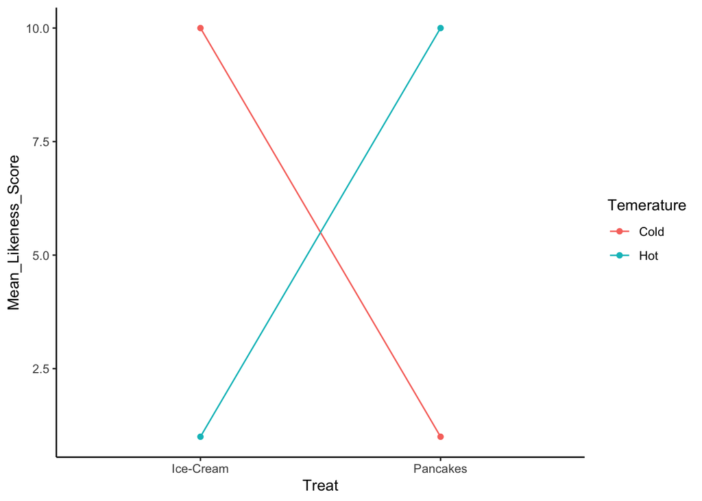

```r
Interaction <- tribble(~Treat, ~Temerature, ~Mean_Likeness_Score,
        "Ice-Cream", "Hot", 1,
        "Ice-Cream", "Cold", 10,
        "Pancakes", "Hot", 10,
        "Pancakes", "Cold", 1,
        )

ggplot(Interaction, aes(x=Treat, y=Mean_Likeness_Score, group=Temerature, color=Temerature))+
  geom_point()+
  geom_line()+
  theme_classic()
```

4. Say you decided to change the first experiment a little bit. You want to see if a more distinct flavor (IV-2) will have an effect on your DV. Instead of a vanilla you offer a beef flavor! Turned out, people still like ice-cream as much as they like milkshakes (IV-1), but they would rather have both of these treats taste like strawberries (no offense to your beef flavor idea!).

This is an example of a main effect of one independent variable (IV-2, Flavor).

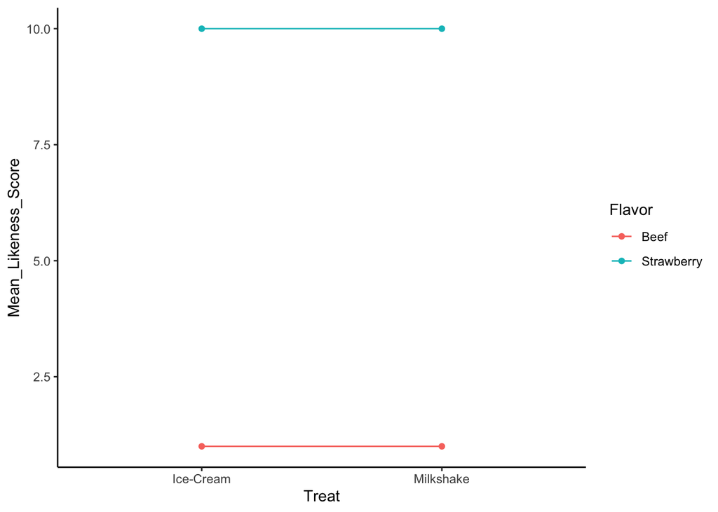

```r
Main_effect_B <- tribble(~Treat, ~Flavor, ~Mean_Likeness_Score,
        "Ice-Cream", "Strawberry", 10,
        "Ice-Cream", "Beef", 1,
        "Milkshake", "Strawberry", 10,
        "Milkshake", "Beef", 1,
        )

ggplot(Main_effect_B, aes(x=Treat, y=Mean_Likeness_Score, group=Flavor, color=Flavor))+
  geom_point()+
  geom_line()+
  theme_classic()
```

5. Similar thing is most likely to happen if you manipulate your treat variable (IV-1) and offer Ramen instead of milkshakes, but keep the flavors from the first experiment (strawberry and vanilla, IV-2). My guess is that people would still like ice-cream of both flavors, but vanilla or strawberry Ramen most likely won’t be a hit.

This would be an example of a main effect of another independent variable (IV-1, Treat).

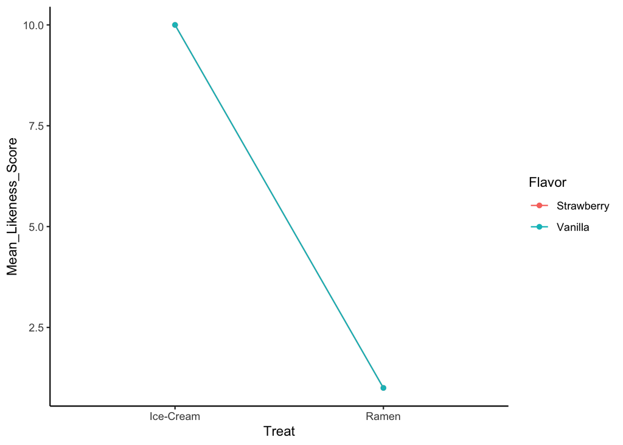

```r
Main_effect_A <- tribble(~Treat, ~Flavor, ~Mean_Likeness_Score,
        "Ice-Cream", "Strawberry", 10,
        "Ice-Cream", "Vanilla", 10,
        "Ramen", "Strawberry", 1,
        "Ramen", "Vanilla", 1,
        )

ggplot(Main_effect_A, aes(x=Treat, y=Mean_Likeness_Score, group=Flavor, color=Flavor))+
  geom_point()+
  geom_line()+
  theme_classic()
```

6. Being a very curious experimenter, you decided to change a Treat variable (IV-1) in the experiment with temperature (IV-2). So you offer people hot and old coffee and milkshakes. Results showed that on average people like coffee as much as they like milkshake. The day was hot, so most people preferred cold coffee, but some still did choose a hot coffee. However, people exhibited a very strong preference for cold milkshakes rather than hot milkshakes.

This is an example of an interaction effect together with a main effect of Temperature (IV-2).

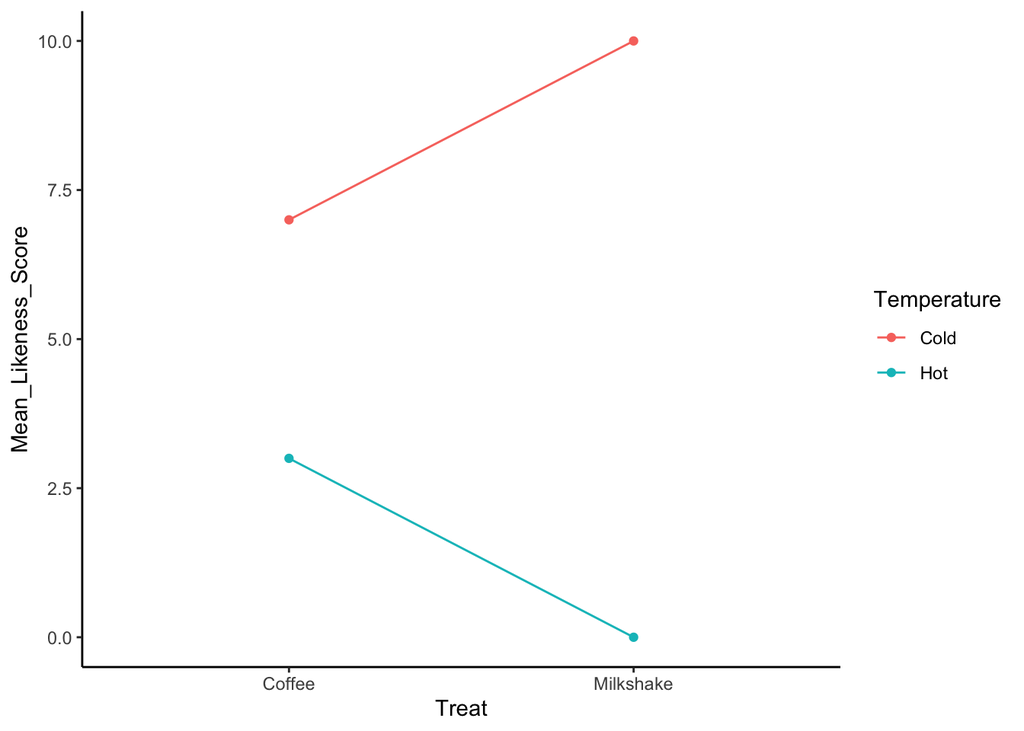

```r
Main_effect_B_and_Interaction <- tribble(~Treat, ~Temperature, ~Mean_Likeness_Score,
        "Milkshake", "Cold", 10,
        "Milkshake", "Hot", 0,
        "Coffee", "Cold", 7,
        "Coffee", "Hot", 3,
        )

ggplot(Main_effect_B_and_Interaction, aes(x=Treat, y=Mean_Likeness_Score, group=Temperature, color=Temperature))+
  geom_point()+
  geom_line()+
  theme_classic()
```

7. You then perform a similar experiment on a cold winter day in Vermont. You want to see if the temperature of the drink (IV-1) will have an effect on how much people like the treat you offer. Instead of milkshakes, you offer tea (IV-2). Turned out that on average, people preferred hot drinks to cold drinks. Interestingly, hot tea was rated higher than hot coffee. Cold tea, however, was less preferable than cold coffee.

This is an example of a main effect of IV-1(Temperature) and interaction effect.

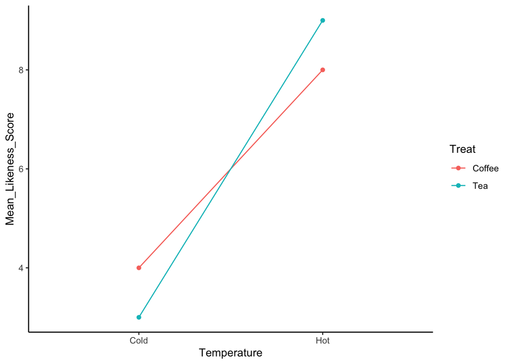

```r
Main_effect_A_and_Interaction <- tribble(~Temperature, ~Treat, ~Mean_Likeness_Score,
        "Hot", "Coffee", 8,
        "Hot", "Tea", 9,
        "Cold", "Coffee", 4,
        "Cold", "Tea", 3,
        )

ggplot(Main_effect_A_and_Interaction, aes(x=Temperature, y=Mean_Likeness_Score, group=Treat, color=Treat))+
  geom_point()+
  geom_line()+
  theme_classic()
```

8. Finally your friend in New York decides to replicate the previous experiment. His results showed that people still preferred hot drinks to cold drinks. However, hot coffee was rated higher than hot tea AND cold coffee was rated higher than cold tea (I guess New-Yorkers are coffee drinkers after all!).

This is an example of two main effects (IV-1, Treat and IV-2, Temperature) and interaction effect.

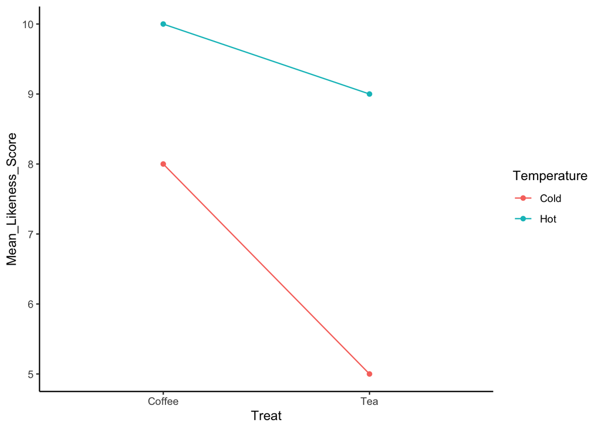

```r
Main_effect_A_and_B_and_Interaction <- tribble(~Treat, ~Temperature, ~Mean_Likeness_Score,
        "Coffee", "Cold", 8,
        "Coffee", "Hot", 10,
        "Tea", "Cold", 5,
        "Tea", "Hot", 9,
        )

ggplot(Main_effect_A_and_B_and_Interaction, aes(x=Treat, y=Mean_Likeness_Score, group=Temperature, color=Temperature))+
  geom_point()+
  geom_line()+
  theme_classic()
```

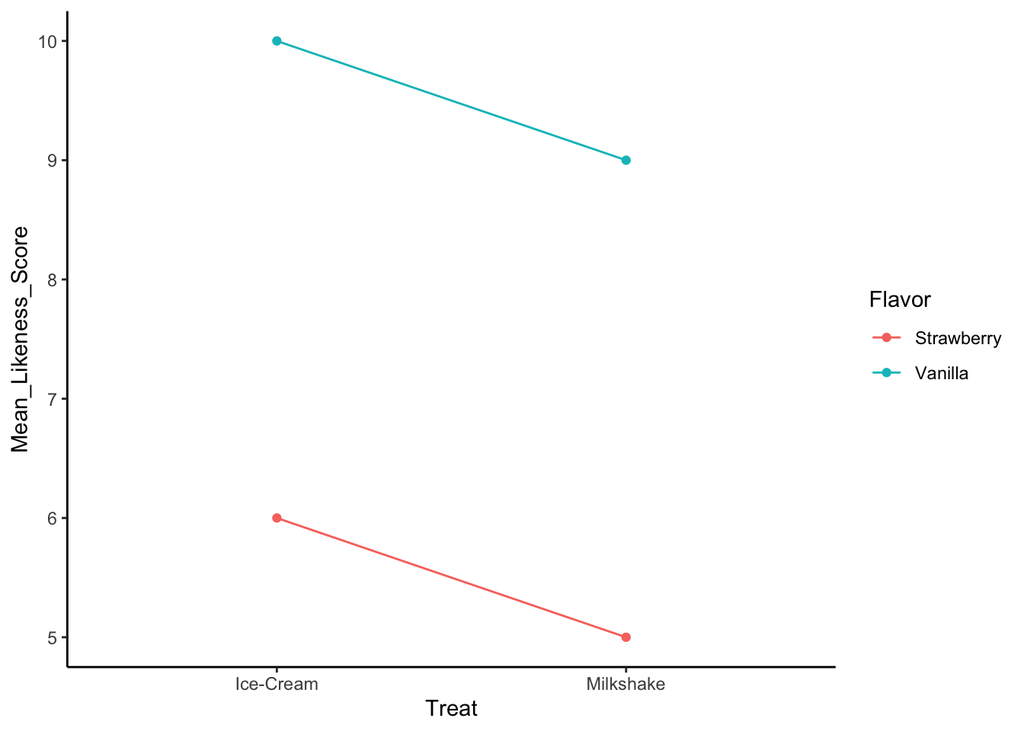

```r
Main_effect_A_and_B <- tribble(~Treat, ~Flavor, ~Mean_Likeness_Score,
        "Ice-Cream", "Strawberry", 6,
        "Ice-Cream", "Vanilla", 10,
        "Milkshake", "Strawberry", 5,
        "Milkshake", "Vanilla", 9,
        )

ggplot(Main_effect_A_and_B, aes(x=Treat, y=Mean_Likeness_Score, group=Flavor, color=Flavor))+
  geom_point()+
  geom_line()+
  theme_classic()
```

### Problem 2

2. Complete the 2x2 factorial lab found here https://crumplab.github.io/statisticsLab/lab-10-factorial-anova.html, up to section 10.4.8. More specifically, your task is to follow that lab exercise to load in the data, transform the data into long-format, conduct a 2x2 between subjects ANOVA, and write a short results section reporting the main effects and interaction. (3 points)

```r
library(data.table)
library(tidyr)
library(dplyr)
```

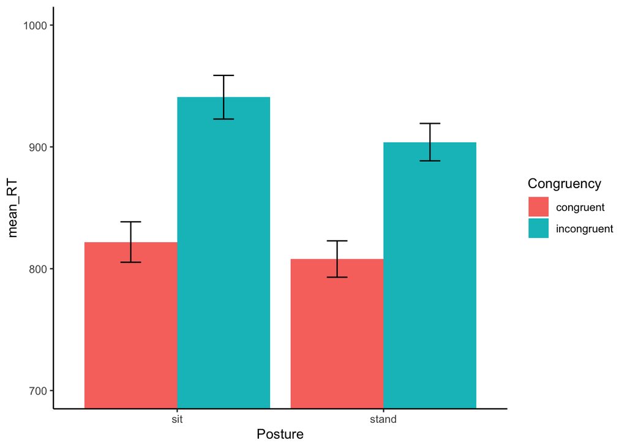

```r
library(ggplot2)

all_data <- fread("data/stroop_stand.csv")


RTs <- c(as.numeric(unlist(all_data[,1])),
         as.numeric(unlist(all_data[,2])),
         as.numeric(unlist(all_data[,3])),
         as.numeric(unlist(all_data[,4]))
         )

Congruency <- rep(rep(c("Congruent","Incongruent"),each=50),2)
Posture <- rep(c("Stand","Sit"),each=100)
Subject <- rep(1:50,4)

stroop_df <- data.frame(Subject,Congruency,Posture,RTs)

stroop_long<- gather(all_data, key=Condition, value=RTs,
                     congruent_stand, incongruent_stand,
                     congruent_sit, incongruent_sit)

new_columns <- tstrsplit(stroop_long$Condition, "_", names=c("Congruency","Posture"))
stroop_long <- cbind(stroop_long,new_columns)
stroop_long <- cbind(stroop_long,Subject=rep(1:50,4))

plot_means <- stroop_long %>%
            group_by(Congruency,Posture) %>%
            summarise(mean_RT = mean(RTs),
                      SEM = sd(RTs)/sqrt(length(RTs)))
ggplot(plot_means, aes(x=Posture, y=mean_RT, group=Congruency, fill=Congruency))+
  geom_bar(stat="identity", position="dodge")+
  geom_errorbar(aes(ymin=mean_RT-SEM, ymax=mean_RT+SEM),
                position=position_dodge(width=0.9),
                width=.2)+
  theme_classic()+
  coord_cartesian(ylim=c(700,1000))
```

```r
aov_out<-aov(RTs ~ Congruency*Posture, stroop_long)
summary_out<-summary(aov_out)
summary_out
```

```
##                     Df  Sum Sq Mean Sq F value   Pr(>F)
## Congruency           1  576822  576822  43.734 3.49e-10 ***
## Posture              1   32303   32303   2.449    0.119
## Congruency:Posture   1    6560    6560   0.497    0.481
## Residuals          196 2585080   13189
## ---
## Signif. codes:  0 '***' 0.001 '**' 0.01 '*' 0.05 '.' 0.1 ' ' 1
```

### Problem 3

3. In chapter 10 of Crump et al. (2018), there is a discussion of patterns of main effects and interactions that can occur in a 2x2 design, which represents perhaps the simplest factorial design. There are 8 possible outcomes discussed https://crumplab.github.io/statistics/more-on-factorial-designs.html#looking-at-main-effects-and-interactions. Examples of these 8 outcomes are shown in two figures, one with bar graphs, and one with line graphs. Reproduce either of these figures using ggplot2. (3 points)

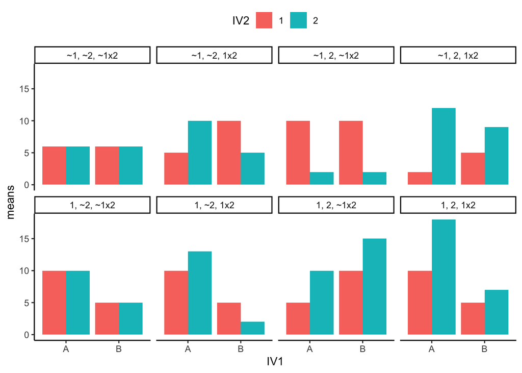

```r
p1<- data.frame(IV1 = c("A","A","B","B"),
                IV2 = c("1","2","1","2"),
                means = c(6,6,6,6))
p2<- data.frame(IV1 = c("A","A","B","B"),
                IV2 = c("1","2","1","2"),
                means = c(10,10,5,5))
p3<- data.frame(IV1 = c("A","A","B","B"),
                IV2 = c("1","2","1","2"),
                means = c(10,13,5,2))
p4<- data.frame(IV1 = c("A","A","B","B"),
                IV2 = c("1","2","1","2"),
                means = c(5,10,10,15))
p5<- data.frame(IV1 = c("A","A","B","B"),
                IV2 = c("1","2","1","2"),
                means = c(10,18,5,7))
p6<- data.frame(IV1 = c("A","A","B","B"),
                IV2 = c("1","2","1","2"),
                means = c(10,2,10,2))
p7<- data.frame(IV1 = c("A","A","B","B"),
                IV2 = c("1","2","1","2"),
                means = c(2,12,5,9))
p8<- data.frame(IV1 = c("A","A","B","B"),
                IV2 = c("1","2","1","2"),
                means = c(5,10,10,5))
all_22s <- rbind(p1,p2,p3,p4,p5,p6,p7,p8)
type <- c(rep("~1, ~2, ~1x2",4),
          rep("1, ~2, ~1x2",4),
          rep("1, ~2, 1x2",4),
          rep("1, 2, ~1x2",4),
          rep("1, 2, 1x2",4),
          rep("~1, 2, ~1x2",4),
          rep("~1, 2, 1x2",4),
          rep("~1, ~2, 1x2",4))
type<-as.factor(type)
all_22s <- cbind(all_22s,type)
ggplot(all_22s, aes(x=IV1, y=means, group=IV2, fill=IV2))+
  geom_bar(stat="identity", position="dodge")+
  theme_classic()+
  facet_wrap(~type, nrow=2)+
  theme(legend.position = "top")
```

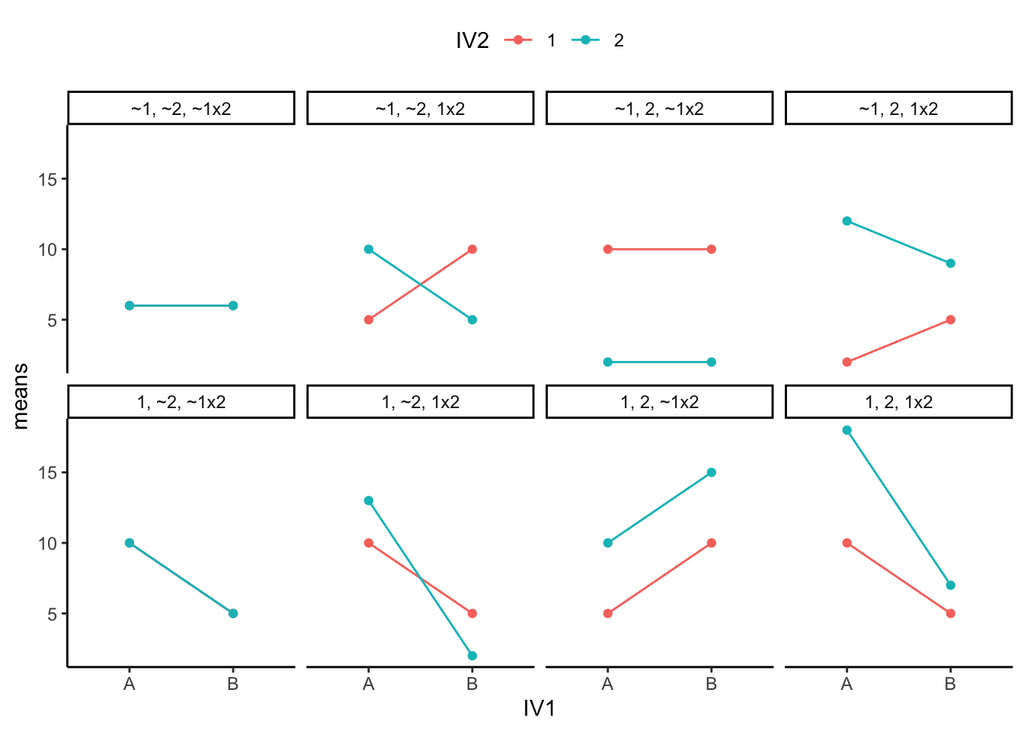

```r
ggplot(all_22s, aes(x=IV1, y=means, group=IV2, color=IV2))+
  geom_point()+
  geom_line()+
  theme_classic()+
  facet_wrap(~type, nrow=2)+
  theme(legend.position = "top")
```

### Problem 4

4. In the conceptual section of this lab we used an R simulation to find the family-wise type I error rate for a simple factorial design with 2 independent variables. Use an R simulation to find the family-wise type I error rate for a factorial design with 3 independent variables. (3 points)

```r
sims <- rbinom(10000,7, 0.05)
length(sims[sims >0])/10000
```

```
## [1] 0.2993
```

```r
sims <- rbinom(10000,15, 0.05)
length(sims[sims >0])/10000
```

```
## [1] 0.5358
```

```r
save_sim <- tibble()

for(i in 1:1000){
  n <- 12
  factorial_data <- tibble(A = factor(rep(c("L1","L2"), each = n)),
                         B = factor(rep(rep(c("L1","L2"), each = n/2),2)),
                         C = factor(rep(c("L1","L2"), n)),
                         DV = rnorm(n*2,0,1))
  # compute ANOVA
  output <- summary(aov(DV ~ A*B*C, data = factorial_data))


  #save p-values for each effect
  sim_tibble <- tibble(p_vals = output[[1]]$`Pr(>F)`[1:7],
                       effect = c("A","B","C","AxB", "AxC", "BxC","AxBxC"),
                       sim = rep(i,7))

  #add the saved values to the overall tibble
  save_sim <-rbind(save_sim,sim_tibble)
}

type_I_errors <- save_sim%>%
  filter(p_vals<0.05)%>%
  group_by(sim)%>%
  count()

dim(type_I_errors)[1]/1000
```

```
## [1] 0.304
```